# Spatial Data Analysis with R. Assignment 2

Violeta Ana Luz Sosa León

April 22, 2019

# Exercises for the meeting of April 26, 2019

The reading material for this exercise is the second part of “Introduction to R” (ch 7-12), found from the R home page or https://cran.r-project.org/doc/manuals/r-release/R-intro.html

Upload your answer to the LearnWeb assigned as a zip file with two files in it: (i) an R markdown file and (ii) an HTML file that resulted from knitting the R Markdown file. (If this is problematic, use PDF or something else.)

## Exercise 1

Create CSV file, read it and assign it to an object called test

```r
#Load the library for reading files
library(readr)

#Initial file path. All the path should be written down in case it is not contained in the working directory
#test <- read_csv("Master/Europa/Clases Alemania/R/Scripts/programmingds/excersise 2/test.csv")

#Case when uncompress the file is in the working directory
test <- read_csv("test.csv")
test
```

```
## # A tibble: 4 x 2
##   width lenght
##   <dbl>  <dbl>
## 1    10     15
## 2    12     27
## 3    11     20
## 4    13     22
```

```r
#If is needed to create the CSV from R, along with a data.frame the code is:
csvdata<-data.frame(width=c(10,12,11,13),lenght=c(15,27,20,22))
write.csv(csvdata,'testData.csv')

#CSV generated
list.files(getwd(), pattern = "\\.csv$")
```

```
## [1] "test.csv"     "testData.csv"
```

## Exercise 2

Create the same object using data.frame function

```r
test<-data.frame(width=c(10,12,11,13),lenght=c(15,27,20,22))

test
```

```
##   width lenght
## 1    10     15
## 2    12     27
## 3    11     20
## 4    13     22
```

## Exercise 3

Carry out a linear regression of width (y) against length (x), and interpret the results

```r
linear_regression <- lm(width ~ lenght, data = test)

summary(linear_regression)
```

```
##
## Call:
## lm(formula = width ~ lenght, data = test)
##
## Residuals:
##       1       2       3       4
## -0.3649 -0.6351 -0.3108  1.3108
##
## Coefficients:
##             Estimate Std. Error t value Pr(>|t|)
## (Intercept)   7.5270     2.7019   2.786    0.108
## lenght        0.1892     0.1260   1.501    0.272
##
## Residual standard error: 1.084 on 2 degrees of freedom
## Multiple R-squared:  0.5297, Adjusted R-squared:  0.2946
## F-statistic: 2.253 on 1 and 2 DF,  p-value: 0.2722
```

## Exercise 4

Add a factor variable *f* to test, with levels *(‘a’,‘a’,‘b’,“b”)* and, run a linear regression of width (y) against length and f(x), and interpret the results.

```r
test$f<-as.factor(c("a","a","b","b"))
factor_linear_regression <- lm(width ~ lenght+f, data = test)

summary(factor_linear_regression)
```

```
##
## Call:
## lm(formula = width ~ lenght + f, data = test)
##
## Residuals:
##       1       2       3       4
##  0.1351 -0.1351 -0.8108  0.8108
##
## Coefficients:
##             Estimate Std. Error t value Pr(>|t|)
## (Intercept)   7.0270     2.9545   2.378    0.253
## lenght        0.1892     0.1351   1.400    0.395
## fb            1.0000     1.1625   0.860    0.548
##
## Residual standard error: 1.162 on 1 degrees of freedom
## Multiple R-squared:  0.7297, Adjusted R-squared:  0.1892
## F-statistic:  1.35 on 2 and 1 DF,  p-value: 0.5199
```

## Exercise 5

Create a data vector with 500 random values, drawn from a *t* distribution with 5 degrees of freedom (and zero non-centrality).

```r
randomStud<-rt(n=500,df=5,ncp = 0)
randomStud
```

[output not shown]

[output cut: 85 more lines]

## Exercise 6

Plot this vector with *qqnorm*, add the reference line with *qqline* and interpret the resulting distribution in the context of the normal distribution.

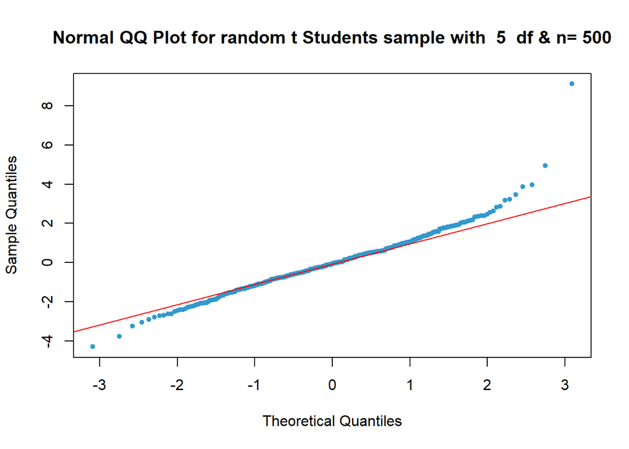

```r
qqnorm(randomStud, main=paste("Normal QQ Plot for random t Students sample with ",5," df & n=",500), col="#3399CC", pch=20)
qqline(randomStud,col="red")
```

*The plot displays the data along with the *qqline* indicating a low variation in general but also more extreme values than expected in the context of normal distribution at the extremities.*

## Exercise 7

Write a function called plot t that combines these steps: it should accept two parameters, *n* (with default value 500) and *df* (with default value 5), and create the *qqnorm* plot with the added line. Demonstrate the function with default parameter values, and with parameter values 1000 and 10.

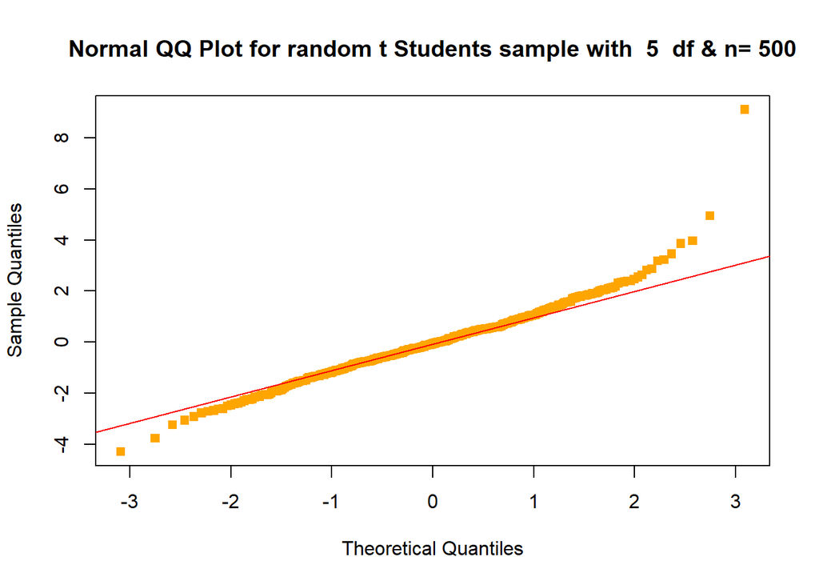

```r
#Function definition
plot_t<-function(n=500, df=5){
  data<-rt(n,df,ncp = 0)
  plot<-qqnorm(randomStud, main=paste("Normal QQ Plot for random t Students sample with ",df," df & n=",n),col="orange", pch=15)
  qqline(randomStud,col="red", add=TRUE)
}

#Function demostration : default values
plot_t()
```

[figure not shown]

```r
#Function demostration : values 1000 and 10
plot_t(1000,10)
```

## Exercise 8

Run this function, while trying to capture the output in a png file with size 800 pixels x 800 pixels.

```r
#Create output file
timeshoot=format(Sys.time(), "%y-%m-%d_%H.%M")
png(paste("vsosa_fplot_",timeshoot, ".png", sep = ""), width = 800, height = 800)

#Execute function to get the plot
plot_t(1000,10)

#Closing the output file
dev.off()
```

```r
#Plot generated:
list.files(getwd(), pattern = "\\.png$")
```

```
## [1] "Rplot.png"                      "Rplot01.png"
## [3] "vsosa_fplot_19-05-17_07.47.png"
```

# References

*Allaire, JJ, Yihui Xie, Jonathan McPherson, Javier Luraschi, Kevin Ushey, Aron Atkins, Hadley Wickham, Joe Cheng, Winston Chang, and Richard Iannone. 2019. Rmarkdown: Dynamic Documents for R.* https://rmarkdown.rstudio.com

*R Documentation* https://www.rdocumentation.org/

*Robert I. Kabacoff. Quick R by DataCamp .* https://www.statmethods.net/index.html

*Yihui Xie, J. J. Allaire, Garrett Grolemund. 2019. R Markdown: The Definitive Guide.* https://bookdown.org/yihui/rmarkdown/

*Zieffler Andrew. R Markdown Theme Gallery* http://www.datadreaming.org/post/r-markdown-theme-gallery/